# Cyclistic_Bike_Share_Case_Study

James Souder

2023-04-27

### Business Task

- **What is the problem you are trying to solve?** To understand how annual riders and casual cyclists differ.
- **How can your insights drive business decisions?** They can be used to develop a marketing strategy aimed at converting casual riders.

**Statement of the business task:** Understand the differences in annual riders and casual riders to develop a marketing strategy to convert casual to annual riders.

### Prepare

```r
# Read and merge multiple csv files
  # df <- list.files(path='C:/my/path/to/files') %>%
  # lapply(read_csv) %>%
  # bind_rows

# Only using most recent month of data for computational efficiency
df <- read_csv("~/Desktop/data_analyst_course/cyclistic_bike_case_study/data/202303-divvy-tripdata.csv")
names(df)

# check for duplicate ride IDs
n_occur <- data.frame(table(df$ride_id))
n_occur[n_occur$Freq > 1,]

#Sort the data
df <- df %>% arrange(started_at)
```

**Description of data**

- The data is hosted at https://divvy-tripdata.s3.amazonaws.com/index.html. It is updated in monthly intervals and is collected directly from Cyclistic.
- Data integrity: The accuracy, completeness, consistency, and trustworthiness of data throughout its life cycle. The data meets all of the criteria for data integrity.
- The data is organized into 13 columns containing information such as bike station, start and finish datetime, and membership status.

### Process

A documentation of cleaning and manipulation of data

The following columns were **created in google sheets**:

- ride_length
- day_of_week

Cleaning data set and feature engineering:

```r
#drop the following cols
df <- df %>% select(-c(ride_id, start_station_id, end_station_id,ended_at))

# Create year, month, day columns
df$Date <- as.Date(df$started_at)
df <- separate(df,Date, c("year","month","day"), sep='-')

# lat degree = 69 miles, long degree = 54.6 miles
df <- df %>% mutate(manhattan_distance_miles = abs(start_lat - end_lat)*69 + abs(start_lng - end_lng)*54.6)
```

### Analysis

```r
drop_na(df) %>% group_by(day_of_week) %>% summarize(mean(ride_length), n=n())
```

```
## # A tibble: 7 × 3
##   day_of_week `mean(ride_length)`     n
##   <chr>       <drtn>              <int>
## 1 Friday      677.3714 secs       29074
## 2 Monday      663.3043 secs       25273
## 3 Saturday    812.7486 secs       18596
## 4 Sunday      814.9230 secs       18928
## 5 Thursday    644.7903 secs       35828
## 6 Tuesday     708.6091 secs       32615
## 7 Wednesday   685.1856 secs       40133
```

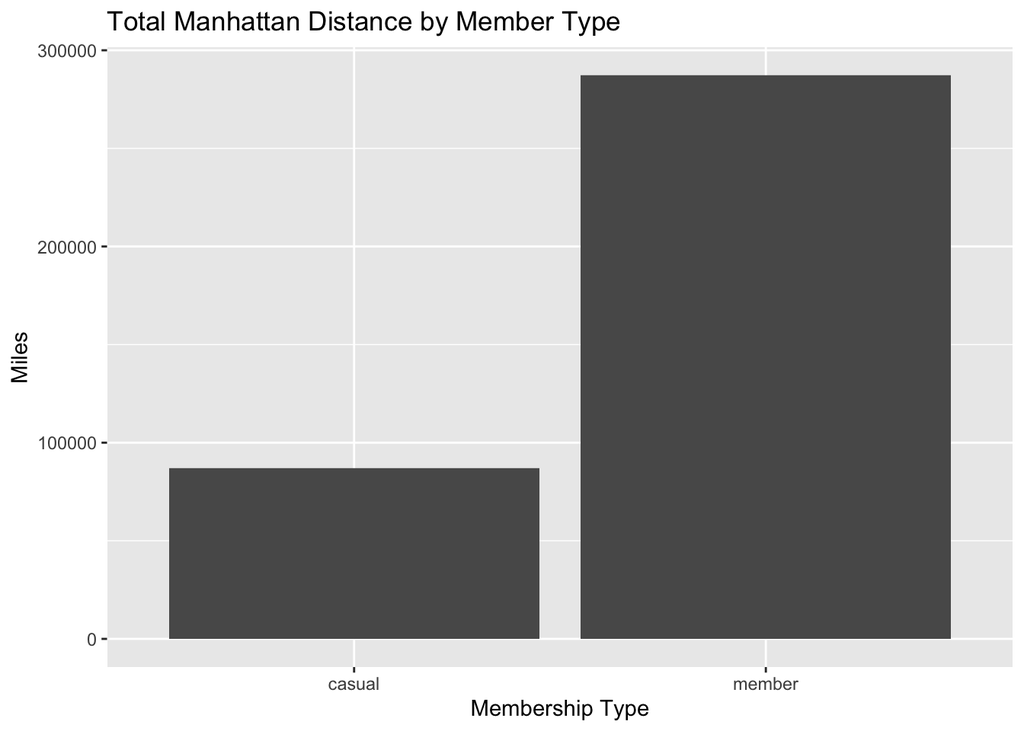

### Share

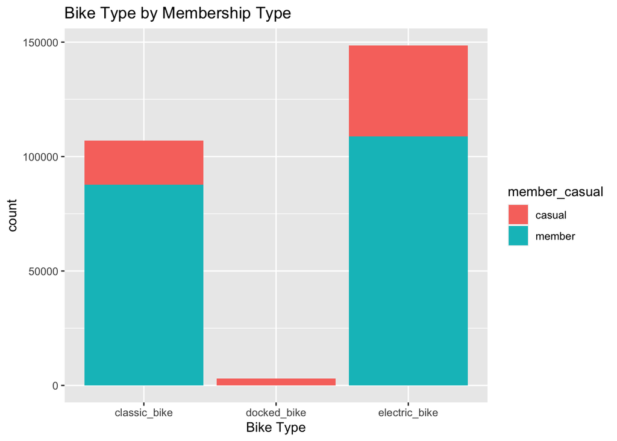

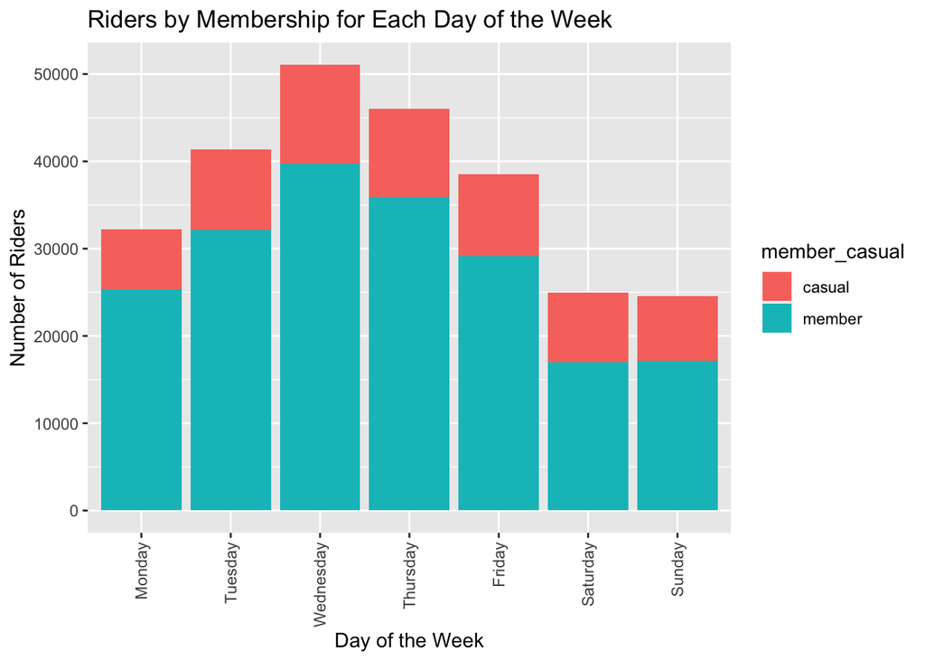

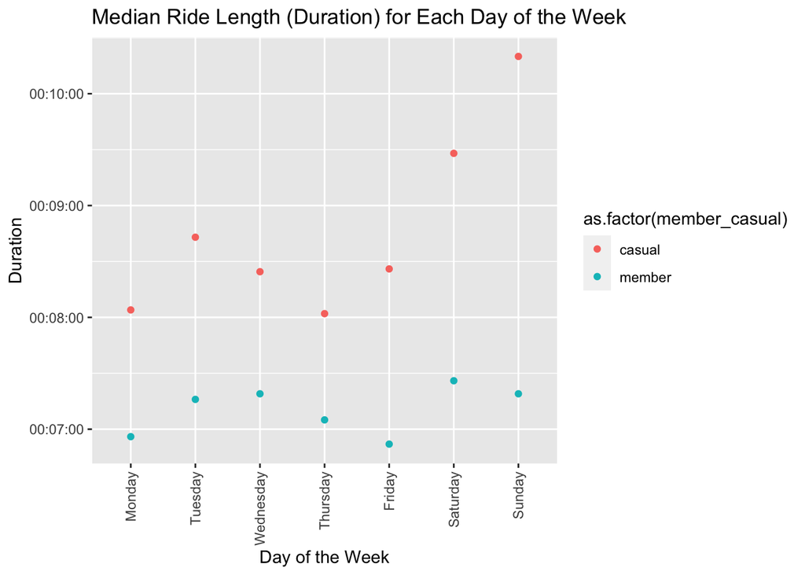

```r
ggplot(data=df,aes(x=factor(day_of_week), y = ride_length, col=as.factor(member_casual))) + stat_summary(fun = "median", geom="point") + labs(title="Median Ride Length (Duration) for Each Day of the Week", y="Duration", x="Day of the Week") + theme(axis.text.x = element_text(angle = 90, vjust = 0.5, hjust=1))
```

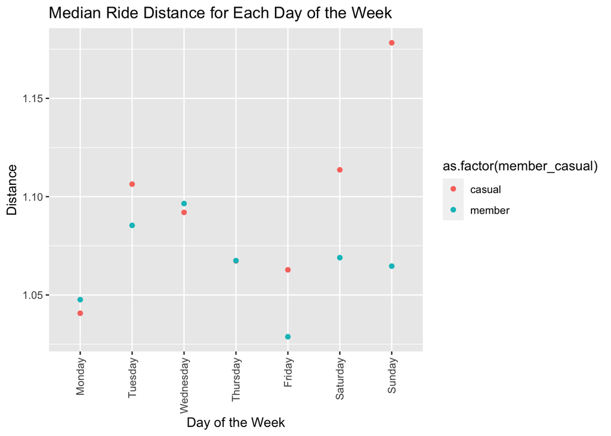

```r
ggplot(data=df,aes(x=factor(day_of_week), y = manhattan_distance_miles, col=as.factor(member_casual))) + stat_summary(fun = "median", geom="point")+ labs(title="Median Ride Distance for Each Day of the Week", y="Distance", x="Day of the Week") + theme(axis.text.x = element_text(angle = 90, vjust = 0.5, hjust=1))
```

### Act

**Top Three Recommendations**

1. Casuals prefer electric bikes. I recommend discount electric bike rentals for members.
2. Membership rides drop off on the weekends, while casual rides stay about the same. Target ads on weekends to convert casual riders.
3. Median ride length and distance spikes for casuals on weekends. Weekend deals for member riders.